# Porject 1 - Analysis of Iris Dataset

Tran Nguyen

## Description of Project

For this project, you will be working with the iris dataset. This dataset contains 150 observations, each of which represents a single flower, which is of one of three iris species: setosa, versicolor, or virginica. The dataset has five columns:

| Variable | Description |
| --- | --- |
| **`Species`** | The species of the flower. |
| **`Petal.Length`** | The length of the petal, measured in cm. |
| **`Petal.Width`** | The width of the petal, measured in cm. |
| **`Sepal.Length`** | The length of the sepal, measured in cm. |
| **`Sepal.Width`** | The width of the sepal, measured in cm. |

Our goal in this project will be to create a linear model that attempts to predict the sepal length based on one of the other three measurements.

## **Part A: Loading and Exploring the Data**

The following line of R code loads the data into a data frame called `iris`.

```r
data(iris)
```

Create a summary of the `iris` data frame.

```r
summary(iris)
```

```
  Sepal.Length    Sepal.Width     Petal.Length    Petal.Width          Species
 Min.   :4.300   Min.   :2.000   Min.   :1.000   Min.   :0.100   setosa    :50
 1st Qu.:5.100   1st Qu.:2.800   1st Qu.:1.600   1st Qu.:0.300   versicolor:50
 Median :5.800   Median :3.000   Median :4.350   Median :1.300   virginica :50
 Mean   :5.843   Mean   :3.057   Mean   :3.758   Mean   :1.199
 3rd Qu.:6.400   3rd Qu.:3.300   3rd Qu.:5.100   3rd Qu.:1.800
 Max.   :7.900   Max.   :4.400   Max.   :6.900   Max.   :2.500
```

## **Part B: Graphical Analysis**

Create a scatter plot that plots sepal length against sepal width.

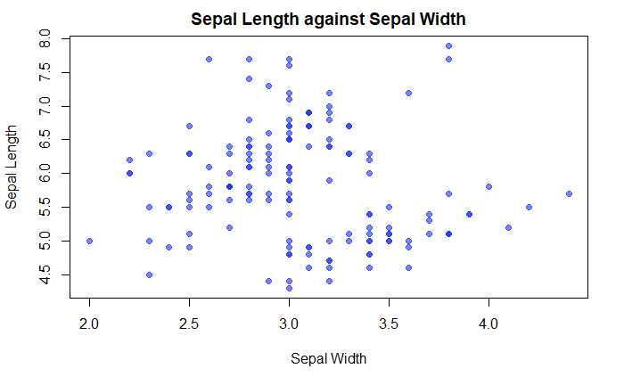

```r
plot(iris$Sepal.Length ~ iris$Sepal.Width, pch=19, col=rgb(0.1, 0.2, 1.0, 0.6), main = "Sepal Length against Sepal Width", xlab="Sepal Width", ylab="Sepal Length")
```

Create a scatter plot that plots sepal length against petal length.

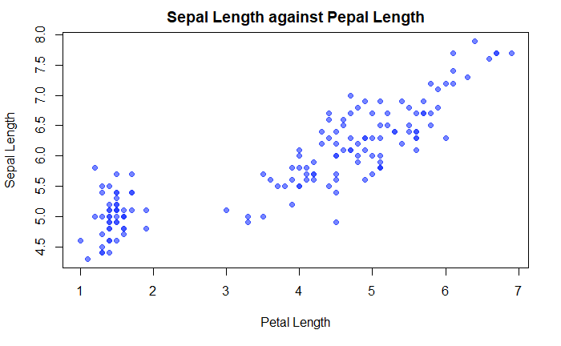

```r
plot(iris$Sepal.Length ~ iris$Petal.Length, pch=19, col=rgb(0.1, 0.2, 1.0, 0.6), main = "Sepal Length against Pepal Length", xlab="Petal Length", ylab="Sepal Length")
```

Create a scatter plot that plots sepal length against petal width.

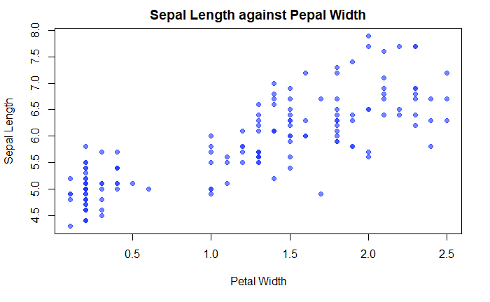

```r
plot(iris$Sepal.Length ~ iris$Petal.Width, pch=19, col=rgb(0.1, 0.2, 1.0, 0.6), main = "Sepal Length against Pepal Width", xlab="Petal Width", ylab="Sepal Length")
```

## **Part C: Create the Linear Models**

We will now generate three regression models. Each model will have sepal length as the response variable, and will have one of the other three measurements as the predictor.

#### **Sepal Length versus Sepal Width**

Use the `lm()` function to create a least-squares model by regressing sepal length against sepal width. Store the model in a variable called `mod1`. Generate a summary of `mod1`.

```r
mod1 <- lm(Sepal.Length ~ Sepal.Width, iris)
summary(mod1)
```

```
Call:
lm(formula = Sepal.Length ~ Sepal.Width, data = iris)

Residuals:
    Min      1Q  Median      3Q     Max
-1.5561 -0.6333 -0.1120  0.5579  2.2226

Coefficients:
            Estimate Std. Error t value Pr(>|t|)
(Intercept)   6.5262     0.4789   13.63   <2e-16 ***
Sepal.Width  -0.2234     0.1551   -1.44    0.152
---
Signif. codes:  0 ‘***’ 0.001 ‘**’ 0.01 ‘*’ 0.05 ‘.’ 0.1 ‘ ’ 1

Residual standard error: 0.8251 on 148 degrees of freedom
Multiple R-squared:  0.01382,   Adjusted R-squared:  0.007159
F-statistic: 2.074 on 1 and 148 DF,  p-value: 0.1519
```

The fitted model is given by the following equation:

$\hat {Sepal.Length} = 6.5262 - 0.2234 \cdot Sepal.Width$

The models tells us that for each additional centimeters in the sepal width, the sepal length decreases by roughly 0.2234 centimeters, on average.

#### **Sepal Length versus Petal Length**

Use the `lm()` function to create a least-squares model by regressing sepal length against petal length. Store the model in a variable called `mod2`. Generate a summary of `mod2`.

```r
mod2 <- lm(iris$Sepal.Length ~ iris$Petal.Length)
summary(mod2)
```

```
Call:
lm(formula = iris$Sepal.Length ~ iris$Petal.Length)

Residuals:
     Min       1Q   Median       3Q      Max
-1.24675 -0.29657 -0.01515  0.27676  1.00269

Coefficients:
                  Estimate Std. Error t value Pr(>|t|)
(Intercept)        4.30660    0.07839   54.94   <2e-16 ***
iris$Petal.Length  0.40892    0.01889   21.65   <2e-16 ***
---
Signif. codes:  0 ‘***’ 0.001 ‘**’ 0.01 ‘*’ 0.05 ‘.’ 0.1 ‘ ’ 1

Residual standard error: 0.4071 on 148 degrees of freedom
Multiple R-squared:   0.76, Adjusted R-squared:  0.7583
F-statistic: 468.6 on 1 and 148 DF,  p-value: < 2.2e-16
```

The fitted model is given by the following equation:

$\hat {Sepal.Length} = 4.3066 + 0.4089 \cdot Petal.Length$

The models tells us that for each additional centimeters in the petal length, the sepal length increases by roughly 0.4089 centimeters, on average.

The r-squared value is given by `r^2 = 0.76`, which tells us that roughly 76% of the variance in the sepal length is explained by the regression model. This model has quite high predictive value. The residual standard error is equal to 0.4071.

#### **Sepal Length versus Petal Width**

Use the `lm()` function to create a least-squares model by regressing sepal length against petal width. Store the model in a variable called `mod3`. Generate a summary of `mod3`.

```r
mod3 <- lm(iris$Sepal.Length ~ iris$Petal.Width)
summary(mod3)
```

```
Call:
lm(formula = iris$Sepal.Length ~ iris$Petal.Width)

Residuals:
     Min       1Q   Median       3Q      Max
-1.38822 -0.29358 -0.04393  0.26429  1.34521

Coefficients:
                 Estimate Std. Error t value Pr(>|t|)
(Intercept)       4.77763    0.07293   65.51   <2e-16 ***
iris$Petal.Width  0.88858    0.05137   17.30   <2e-16 ***
---
Signif. codes:  0 ‘***’ 0.001 ‘**’ 0.01 ‘*’ 0.05 ‘.’ 0.1 ‘ ’ 1

Residual standard error: 0.478 on 148 degrees of freedom
Multiple R-squared:  0.669, Adjusted R-squared:  0.6668
F-statistic: 299.2 on 1 and 148 DF,  p-value: < 2.2e-16
```

The fitted model is given by the following equation:

$\hat {Sepal.Length} = 4.7776 + 0.8885 \cdot Petal.Width$

The models tells us that for each additional centimeters in the petal width, the sepal length increases by roughly 0.8885 centimeters, on average.

#### **Model Selection**

The model of sepal length against petal length would provide the best fit because it has the highest r-squared value of 0.76, implies that a large portion of the sepal length is explained and can be predicted.

## **Part D: Residual Analysis**

We will now perform an analysis of the residuals in the model you selected above. Begin by creating a residual plot for that model. Add a red, horizontal line to your plot at $y=0$.

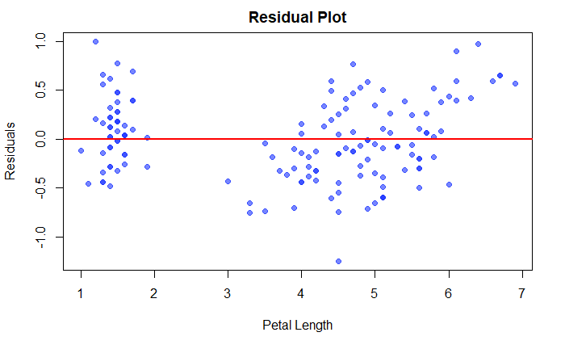

```r
plot(mod2$residuals ~ iris$Petal.Length,
     pch=19, col=rgb(0.1, 0.2, 1.0, 0.6),
     main="Residual Plot", xlab="Petal Length", ylab="Residuals")
abline(h=0, col="red", lwd=2)
```

This residual plot looks good. There seems to be a slightly trend in the residuals. The variance in the residuals appears to be roughly equal across the range of petal length.

We will now attempt to assess the normality of the residuals. Create a histogram of the residuals in your selected model. Set the histogram to have 20 breaks.

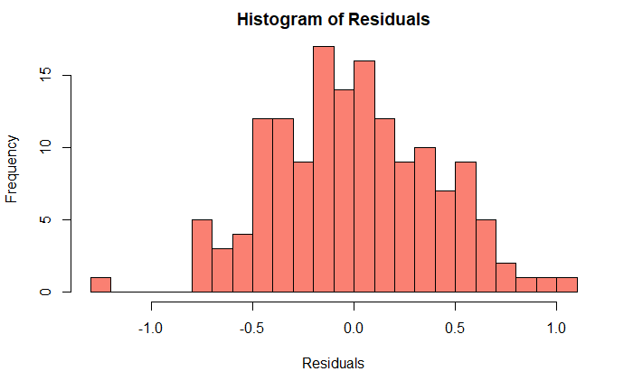

```r
hist(mod2$residuals, breaks=20, col="salmon",
     main="Histogram of Residuals", xlab="Residuals")
```

The histogram provides strong evidence that our residuals are quite normally distributed with a mean of 0, except for that odd value in the far left.

Finally, we create a qqplot plot of the residuals.

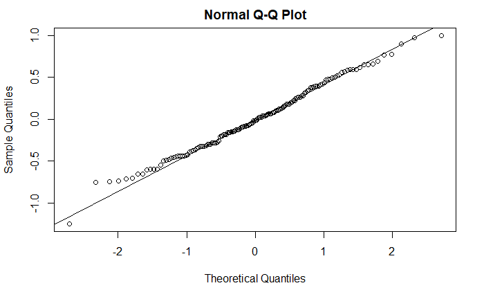

```r
qqnorm(mod2$residuals)
qqline(mod2$residuals)
```

The qqplot strongly suggests that the distribution of residuals is approximately normal. There is some indication that the distribution might be slightly heavy-tailed.

## **Part E: Predictions**

1. Sepal.Width = 3.7, Petal.Length = 1.5, Petal.Width = 0.4
2. Sepal.Width = 3.0, Petal.Length = 4.2, Petal.Width = 1.2
3. Sepal.Width = 2.7, Petal.Length = 5.6, Petal.Width = 1.3

With each prediction, provide a 95% prediction interval for the sepal width.

```r
predict(mod1, newdata = data.frame(Sepal.Width = 3.7, Petal.Length = 1.5, Petal.Width = 0.4), interval = "predict", level = 0.95)
```

```
       fit      lwr      upr
1 5.699787 4.052056 7.347518
```

```r
predict(mod1, newdata = data.frame(Sepal.Width = 3.0, Petal.Length = 4.2, Petal.Width = 1.2), interval = "predict", level = 0.95)
```

```
       fit      lwr      upr
1 5.856139 4.220127 7.492152
```

```r
predict(mod1, newdata = data.frame(Sepal.Width = 2.7, Petal.Length = 5.6, Petal.Width = 1.3), interval = "predict", level = 0.95)
```

```
       fit      lwr      upr
1 5.923148 4.283569 7.562727
```